# Reproducible Research - Peer Assesment 1

## Loading and Preprocessing data

Reading data into activity

```r
activity<-read.csv("C:/Users/lovesh/Documents/activity.csv", header=T)
```

## What is the mean total no.of steps taken per day

First the total(sum) of steps is determined for each day

```r
sum_steps_perday <- tapply(activity$steps, activity$date, sum, na.rm=T)
```

Histogram for the total number of steps is plotted

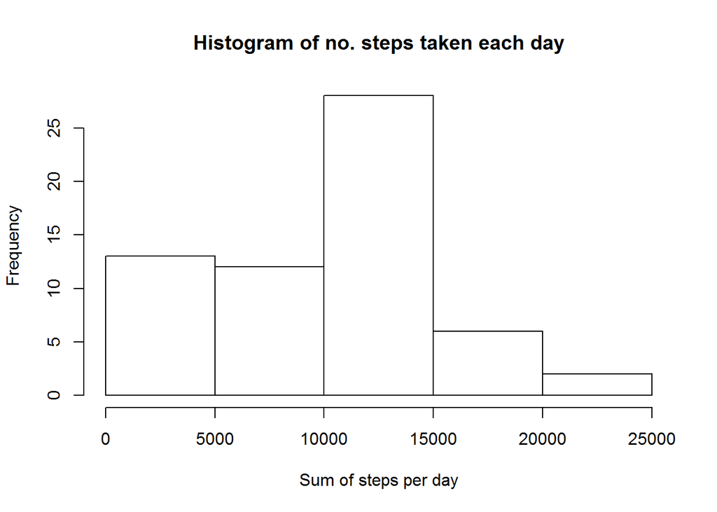

```r
hist(sum_steps_perday, xlab="Sum of steps per day", main="Histogram of no. steps taken each day")
```

The mean and median for the total number of steps taken a day is recorded

```r
mean_stepsperday<- mean(round(sum_steps_perday))
median_stepsperday<- median(round(sum_steps_perday))
mean_stepsperday
```

```
## [1] 9354.23
```

```r
median_stepsperday
```

```
## [1] 10395
```

## What is the average daily pattern

A time series plot of the 5-minute interval and the average number of steps taken (averaged across all days) is shown below:

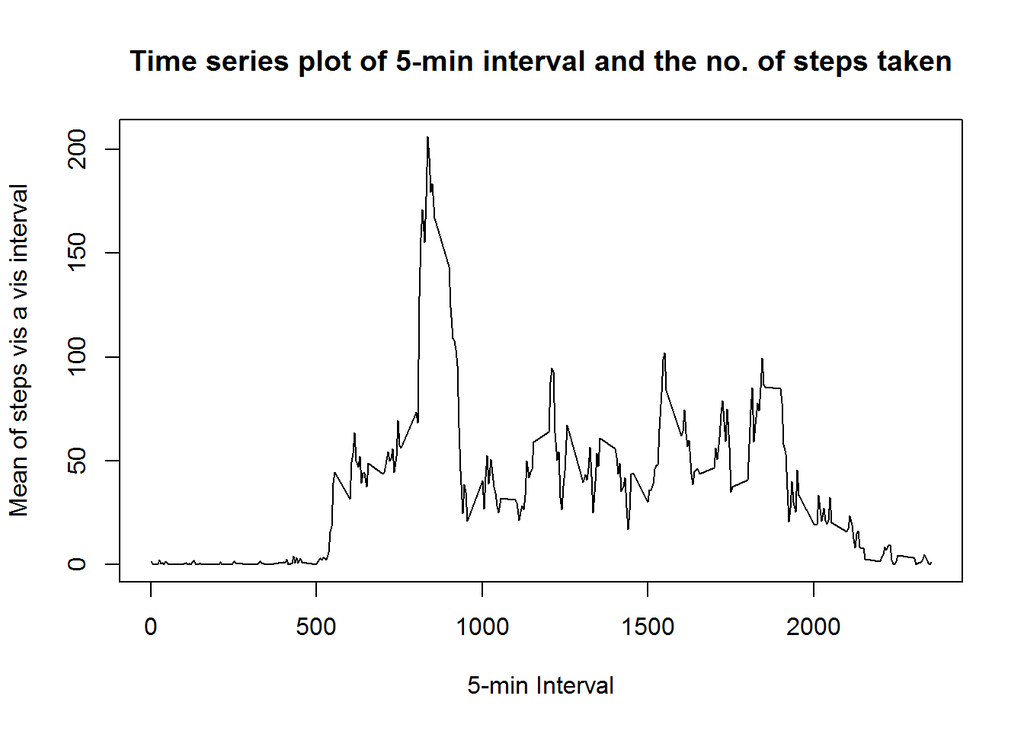

```r
 mean_stepsint<- tapply(activity$steps, activity$interval, mean, na.rm=T)
plot(mean_stepsint ~ unique(activity$interval), type="l", xlab="5-min Interval", ylab="Mean of steps vis a vis interval", main="Time series plot of 5-min interval and the no. of steps taken")
```

The 5-minute interval (on average across all the days in the dataset) that contains the maximum number of steps is the following (below are shown the interval showing the max. number of steps and the value of the max. number of steps):

```r
mean_stepsint[which.max(mean_stepsint)]
```

```
##      835
## 206.1698
```

## Imputing Missing Values

Note that there are a number of days/intervals where there are missing values (coded as NA). The presence of missing days may introduce bias into some calculations or summaries of the data. First, in order to visualize in which variable the NAs are:

```r
table(is.na(activity) == TRUE)
```

```
##
## FALSE  TRUE
## 50400  2304
```

```r
summary(activity)
```

```
##      steps                date          interval
##  Min.   :  0.00   2012-10-01:  288   Min.   :   0.0
##  1st Qu.:  0.00   2012-10-02:  288   1st Qu.: 588.8
##  Median :  0.00   2012-10-03:  288   Median :1177.5
##  Mean   : 37.38   2012-10-04:  288   Mean   :1177.5
##  3rd Qu.: 12.00   2012-10-05:  288   3rd Qu.:1766.2
##  Max.   :806.00   2012-10-06:  288   Max.   :2355.0
##  NA's   :2304     (Other)   :15840
```

All of the NAs are in the steps variable. There are 2304 NAs.

## Strategy for filling in all the missing values in the dataset

The following strategy is chosen: for any NA is the step variable, the mean (of steps) of the corresponding interval is taken as the replacing value. The mean_stepsint contains the mean for each single interval calculated over the 61 days. The right value coming from mean_stepsint is going to be used to replace the NA at the same interval.

```r
activity2<- activity #creation of dataset that will have no more NAs
for(i in 1:nrow(activity)){
     if(is.na(activity$steps[i])){
         activity2$steps[i]<- mean_stepsint[[as.character(activity[i, "interval"])]]
     }
 }
```

Below is a histogram of the total number of steps taken each day. The mean and median total number of steps taken per day are reported.

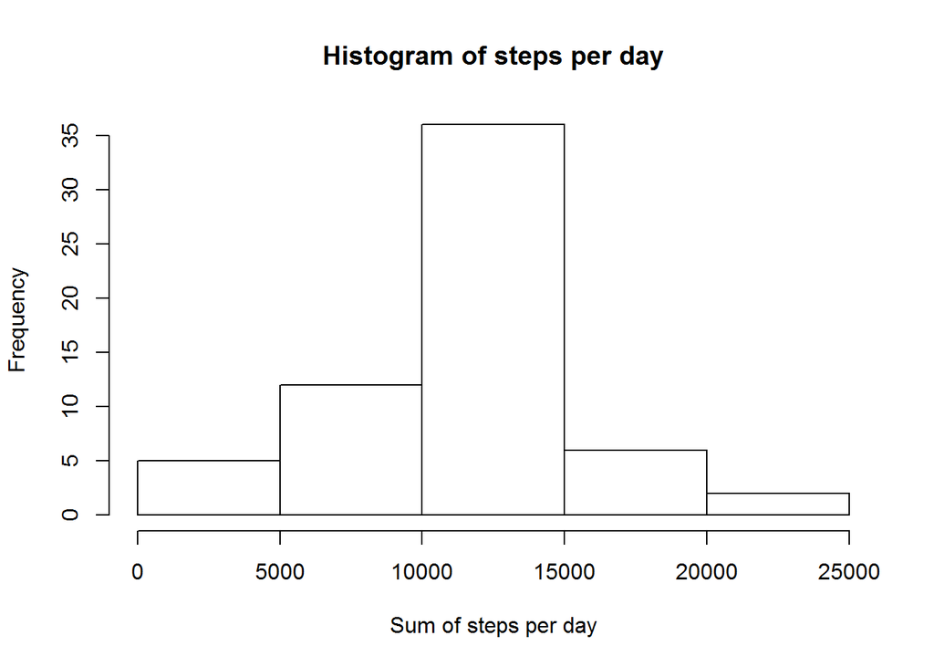

```r
sum_stepsperday_activity2<- tapply(activity2$steps, activity2$date, sum, na.rm=T)
hist(sum_stepsperday_activity2, xlab="Sum of steps per day", main="Histogram of steps per day")
```

```r
mean_stepsperday_activity2<- mean(round(sum_stepsperday_activity2))
median_stepsperday_activity2<- median(round(sum_stepsperday_activity2))
```

The new values are

```r
mean_stepsperday_activity2
```

```
## [1] 10766.16
```

```r
median_stepsperday_activity2
```

```
## [1] 10766
```

In order to compare the new values with the “old” values:

```r
df_summary<-NULL
df_summary<- rbind(df_summary, data.frame(mean= c(mean_stepsperday, mean_stepsperday_activity2), median=c(median_stepsperday, median_stepsperday_activity2)))
colnames(df_summary)<- c("Mean", "Median")
rownames(df_summary)<- c("With NAs", "Without NAs")
df_summary
```

```
##                 Mean Median
## With NAs     9354.23  10395
## Without NAs 10766.16  10766
```